# COVID-19 Project

Ezra Oppenheimer

07/12/2021

# Introduction

In this assignment, we have branched off several different hypotheses into one singular R Markdown file. To keep things organized, and to help differentiate between authors, we have compartmentalized our Rmd into the following sections:

### Ezra Oppenheimer’s Report

## Packages

This project utilizes the following packages. Ensure they are initialized in order for it to work.

```r
library(tidyverse)
library(stringr)
library(lubridate)
library(maps)
library(gridExtra)
library(ISLR)
```

## Datasets

```r
# info about world birthrate
birthrate <- read_tsv("BIRTHRATE.csv")

# full dataset for COVID cases worldwide
covid_cases <- read_csv("https://covid.ourworldindata.org/data/owid-covid-data.csv",
                        col_types = cols(
                          .default = col_double(),
                          date = col_date(format =""),
                          location = col_character()
                        ))

# information regarding COVID vaccinations in particular
covid_vaccs <- read_csv("https://raw.githubusercontent.com/owid/covid-19-data/master/public/data/vaccinations/vaccinations.csv")

# authoritative codebook for the Oxford COVID-19 Government Response Tracker
# EZRA!!! THIS GETS OVERWRITTEN
covid_response <- read_csv("https://raw.githubusercontent.com/OxCGRT/covid-policy-tracker/master/data/OxCGRT_latest.csv",
                           col_types = cols(
                             .default = col_character(),
                             Date = col_date(format = "%Y%m%d"))
                           ) %>%
    mutate(
      across(starts_with("Confirmed"), as.integer),
      across(ends_with("Flag"), as.logical),
      across(ends_with("Index"), as.double),
      across(ends_with("ForDisplay"), as.double),
      )

# cosmetic information about every country, such as names, country codes, and continents.
countries <- read_csv("countries with regional codes.csv") %>%
  select(c("name", "alpha-3", "region")) %>%
  rename(location = name, "iso-code" = "alpha-3", continent = region)


# worldwide fertility @ https://www.humanfertility.org/cgi-bin/stff.php
fertility <- read_csv("humanfertility.csv",
                      col_types = cols(
                        .default = col_double(),
                        CountryCode = col_character()
                      ))

# types of regimes for each region
democracyindex <- read_tsv("DEMOCRACYINDEX.csv")

# population of each country
population <- read_tsv("POPULATION.csv")

# the values in the table are in `% of GDP` of the region.
educationexp <- read_tsv("EDUEXP.csv")

# GDP per capital in the region
gdppp <- read_tsv("GDPPP.csv")

# Public debt in the region
publicdebt <- read_tsv("PUBLICDEBT.csv")

# GINI index in the region
gini <- read_tsv("GINI.csv")
```

# Ezra Oppenheimer Report

*Return to Introduction*

## Hypotheses

For my research, I wanted to tackle a number of hypotheses regarding COVID-19. Two of these stem from conspiracies, whereas the other is more original. Regardless, I hope that with this report, I could shed some light onto these problems:

1. As vaccinations increase, the deaths due to COVID will decrease, however the infections will remain the same.
2. Vaccines do not cause infertility.
3. Authoritarian countries have a lower infection rate than democratic countries.

These are three handy functions which will make filtering easier for future datasets.

```r
isPeriod0 <- function(date) {
  date < ym("2021-05")
}

isPeriod1 <- function(date) {
  date >= ym("2021-05") & date < ym("2021-09")
}

isPeriod2 <- function(date) {
  date >= ym("2021-09")
}
```

## Hypothesis 1

*Return to Hypotheses*

### As vaccinations increase, the deaths due to COVID will decrease, however the infections will remain the same.

I was wondering if vaccines have affected COVID-19’s spread. Conspiracists suggest that vaccines don’t work, *period*. However, I’ve heard elsewhere that vaccines prevent *fatalities*, yet *do not stop infections*.

This is a hard one to pin down scientifically. The raw infection & vaccine data cannot validate the strength of the vaccine, because:

- COVID cases may involve unvaccinated people. (the data doesn’t differentiate these)
- Vaccines may not be widespread in certain regions.
- Missing `total_cases` and `total_deaths` entries, which will hinder accuracy for cumulative sums.

#### Dates

The interval between May 1st, 2021 and September 1st, 2021 is the most effective for this thesis. The vaccine was entering full rollout during early May (at least in Canada). This is where change should really start to occur.

#### Anticipated Factors

As stated above, the number of vaccinated infectees & casualties should play a major role in this statistic. I am only interested in COVID cases & deaths involving vaccinated people, which is hard to come by, since this dataset isn’t courteous to this statistic.

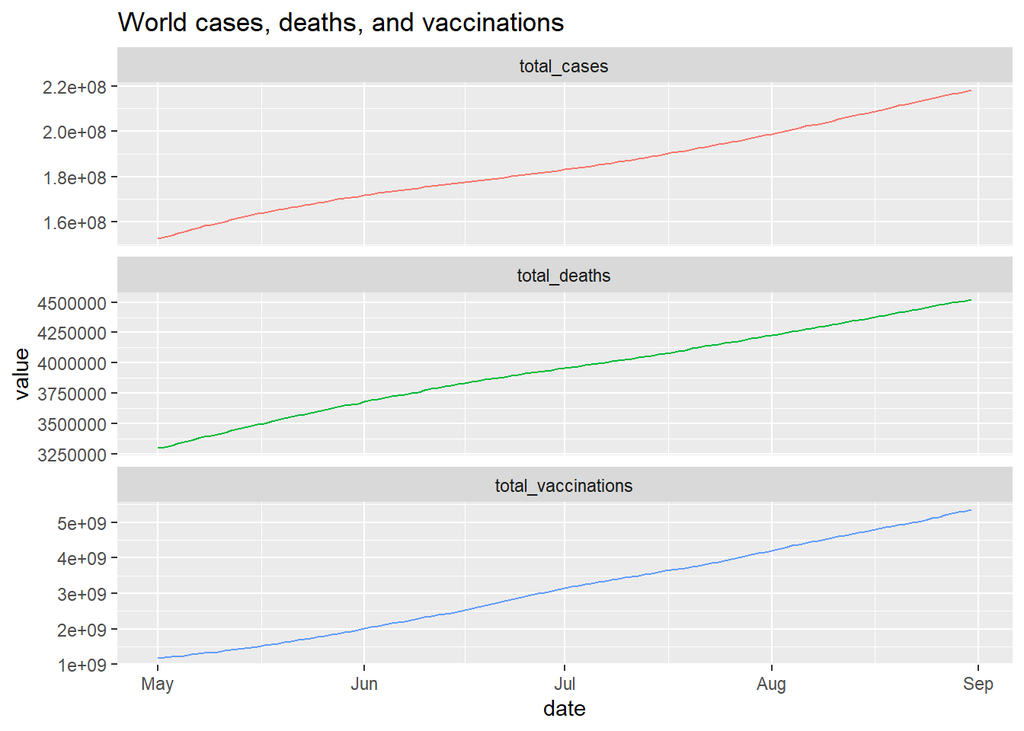

```r
# filters the datasets to our desired time interval
covid_cases1 <- covid_cases %>%
  filter(isPeriod1(date)) %>%
  select(c(location, date, total_cases, total_deaths))

covid_vaccs1 <- covid_vaccs %>%
  filter(isPeriod1(date)) %>%
  select(c(location, date, total_vaccinations))

# joins the relevant datasets into one
covid_joined1 <- covid_cases1 %>%
  inner_join(covid_vaccs1, by = c("location", "date")) %>%
  left_join(countries, by = "location")


# given a vector of locations, this will plot each
hypothesis1 <- function(i) {
  covid_joined2 <- covid_joined1 %>%
    filter(location == i) %>%  # this is where you can select which filter you want, be it countries or continents
    group_by(date) %>%
    summarise(
      total_cases = sum(total_cases, na.rm = TRUE),
      total_deaths = sum(total_deaths, na.rm = TRUE),
      total_vaccinations = sum(total_vaccinations, na.rm = TRUE)
    ) %>%
    gather(c("total_vaccinations", "total_cases", "total_deaths"), key = "key", value = "value")

  (ggplot(covid_joined2, mapping = aes(x = date, group = key, color = key)) +
    ggtitle(str_c(i, " cases, deaths, and vaccinations")) +
    geom_line(mapping = aes(y = value), show.legend = FALSE) +
    facet_wrap(~key, scales = "free_y", ncol = 1))
}

# plot graph
hypothesis1("World") # this "World" statistic is included in the dataset, which accounts for the global statistics
```

From the data above, it’s disheartening to see that vaccines haven’t hindered COVID-19 globally. **This does not mean that vaccines malfunction**. On the contrary, the data could suggest that, despite vaccines being in circulation, we haven’t seen any big change in infections. Perhaps people aren’t being vaccinated, or the vaccine *is* working, but not as effectively as expected.

Let’s try a few more countries as a thought experiment.

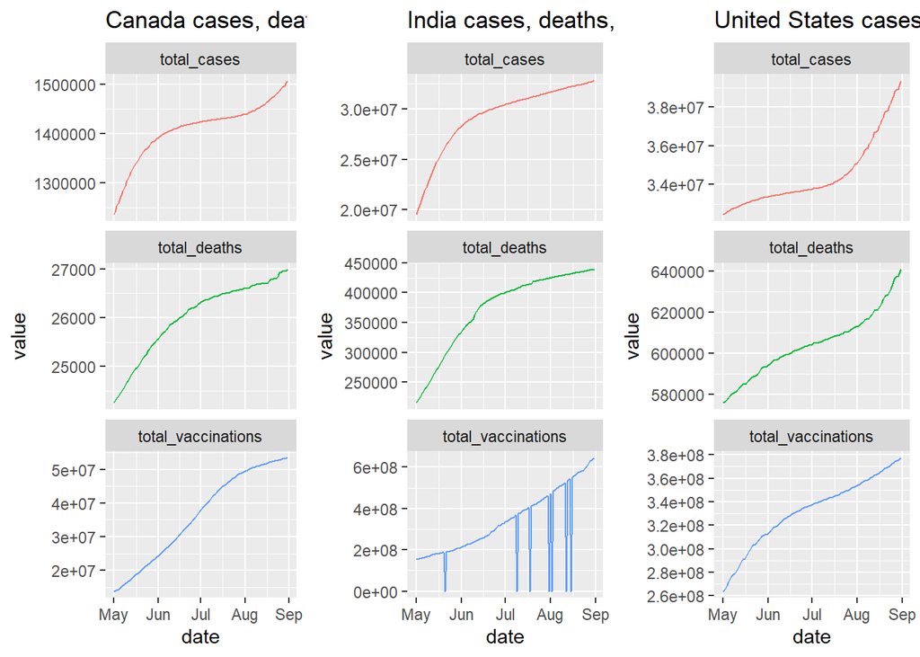

```r
plot1 <- hypothesis1("Canada")
plot2 <- hypothesis1("India")
plot3 <- hypothesis1("United States")
grid.arrange(plot1, plot2, plot3, nrow=1, ncol=3)
```

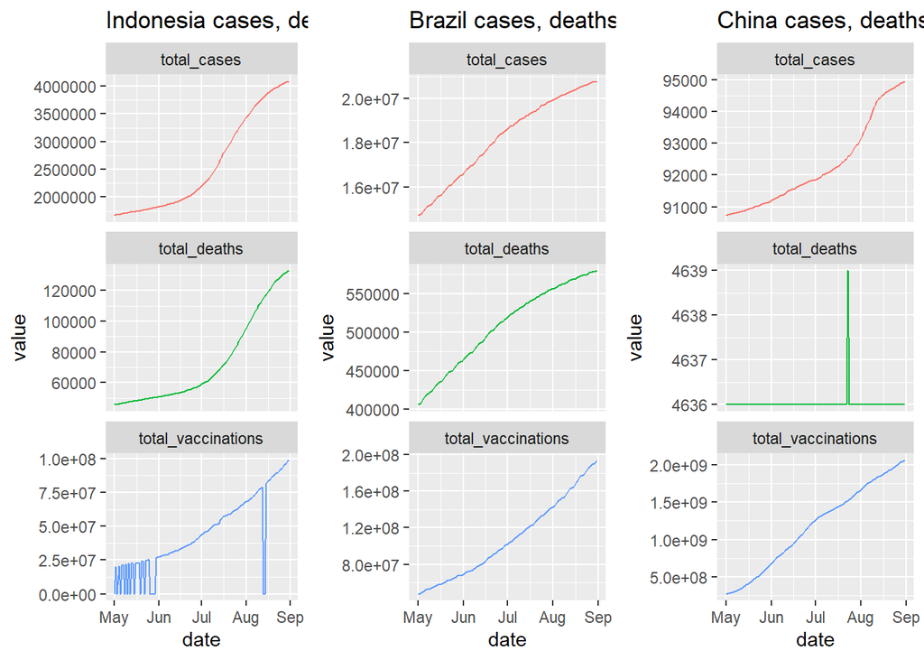

```r
plot4 <- hypothesis1("Indonesia")
plot5 <- hypothesis1("Brazil")
plot6 <- hypothesis1("China")
grid.arrange(plot4, plot5, plot6, nrow=1, ncol=3)
```

HAHAHAhahaha, oh my god… Sorry… I am too fixated by the China statistic. *Despite* COVID originating in China, and *despite* the Chinese government *[literally ghettoizing the Wuhan citizens during COVID’s outbreak](https://youtu.be/wEkIdGht-S8)*, OF COURSE the Wuhan virus would have only killed a couple of thousand people. Got it.

Besides the CCP’s fake data, there seems to be no correlation between the vaccinations and the case & death count. The red and green curves seem to be unaffected by the curvature of the vaccination curve. For these reasons, someone cannot suggest that cases & deaths have gone down due to vaccines.

There are also little graphical glitches in the India and Indonesia graphs. Those would be missing data entries from the `covid_vaccs` dataset. It happens for a lot for this dataset, so I am not particularly surprised. *(Lesson learned, I fix this in Hypothesis 2)*

Overall, the statements that I’ve taken away from this are:

> Vaccines have not stopped the spread of COVID-19 globally. The death rate is still increasing globally, and the infection rate remains unchanged.

Not what I was expecting. I was expecting more middle-ground, but I guess the doom-and-gloomers are right that COVID isn’t getting better.

## Hypothesis 2

*Return to Hypotheses*

### Vaccines do not cause infertility.

Hysteria became rampant when vaccines were introduced. Conspiracists believed that taking the vaccine would depopulate the earth to euthanize the population. I mean, what is there to say, except for us to get into it! :)

#### Dates

So, the dates here are kind of deviating from the DATA-100 assignment. Conception of a child takes approximately 9 months, which means that the data will only be meaningful 9 months after vaccination. As of December 8th, 2021, vaccines have onlt existed for around 10 months, so it is hard to say if I will get any meaningful results using *any* date.

#### Anticipated Factors

I am not expecting there to be a correlation between these two datasets. It is simply cathartic to *see* that there is no depopulation scheme in the works. The only limitation with this is, this cannot confirm *scientifically* that vaccines affect fertility, because:

- Births may involve unvaccinated people. (the data doesn’t differentiate these)
- Vaccines may not be widespread in certain regions.
- Assuming there *is* a decrease in births, it could be chalked up to antinatalist movements, or other factors.

```r
# first I need to tidy the fertility dataset
fertility2 <- fertility %>%
  rename("iso-code" = CountryCode) %>%
  gather("January", "February", "March", "April", "May", "June", "July", "August", "September", "October", "November", "December", key = "month", value = "births") %>%
  mutate(date = ym(str_c(Year, month))) %>%
  inner_join(countries, by = "iso-code") %>%
  select(location, date, births)


# secondly, i was pissed off that `covid_vaccs` contained so many NA entries for total_vaccinations. this was unacceptable, so i interpolated it using a cumulative sum approach. by sampling the daily_vaccinations, i was able to eliminate all NA entries, and it snaps back to its ground-truth value when applicable.
covid_vaccs2 <- tibble(
    location = c(),
    date = c(),
    total_vaccinations = c(),
    interpolated_vaccinations = c()
  )

for (country in unique(covid_vaccs $ location)) {
  temp <- covid_vaccs %>%
    filter(location == country)

  cum_sum <- c(temp $ total_vaccinations [1])
  for (j in 2:length(temp $ daily_vaccinations)) {
      value <- temp $ daily_vaccinations[j]
      if (is.na(value)) {
        value <- 0
      }
      value <- cum_sum[length(cum_sum)] + value

      if (!is.na(temp $ total_vaccinations[j])) {
        value <- temp $ total_vaccinations[j]
      }
      cum_sum <- c(cum_sum, value)
  }

  covid_vaccs2 <- rbind(
    covid_vaccs2,
    tibble(
      location = temp $ location,
      date = temp $ date,
      total_vaccinations = temp $ total_vaccinations,
      interpolated_vaccinations = cum_sum
  ))

}
```

Finally with that out of the way, I can accurately process the data.

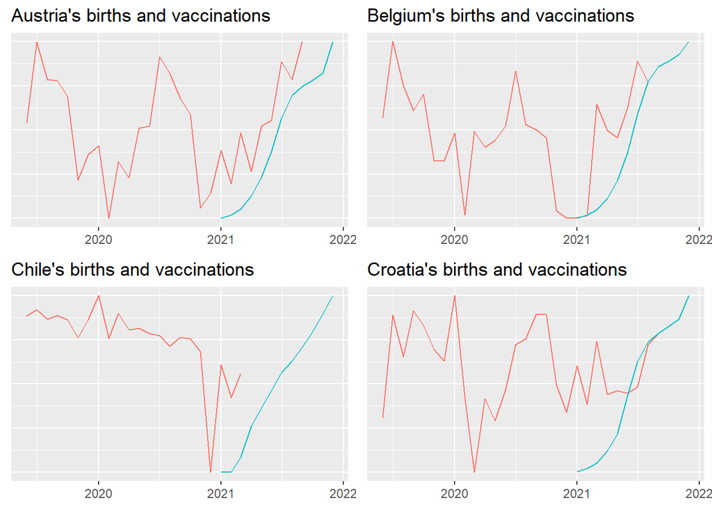

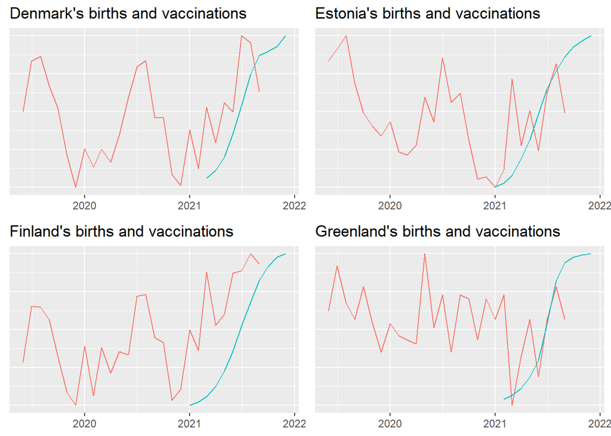

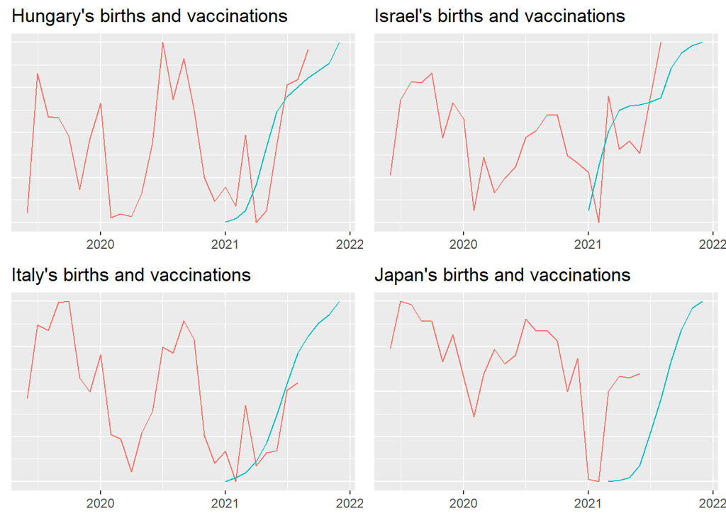

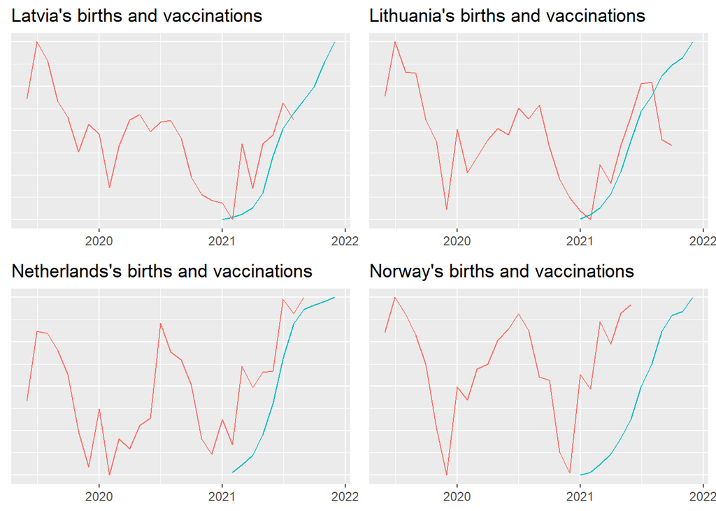

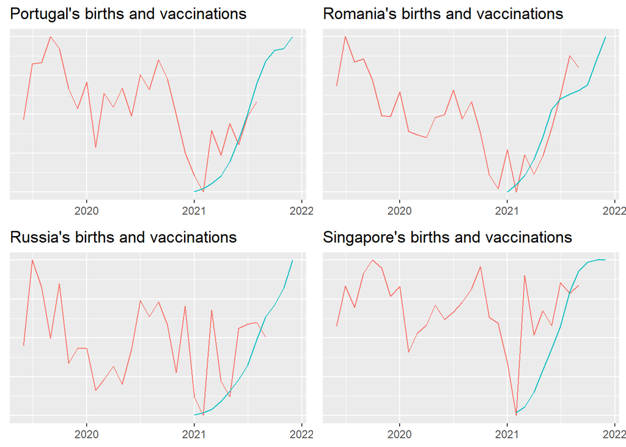

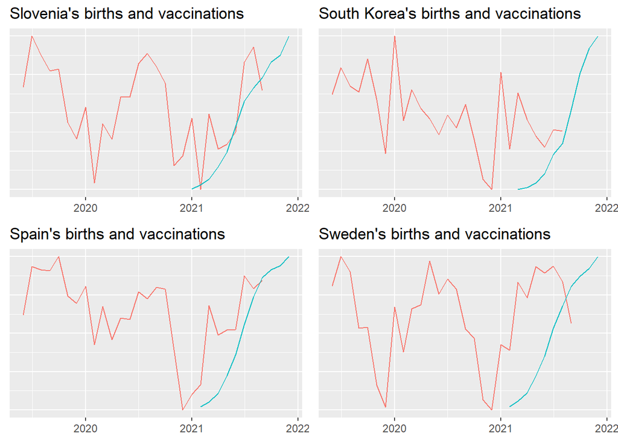

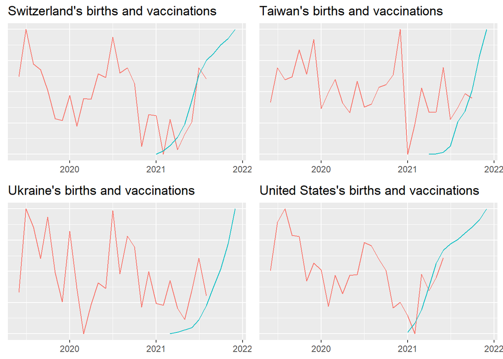

```r
covid_joined1 <- left_join(fertility2, covid_vaccs2, by = c("location", "date")) %>%
  arrange(location, date) %>%
  select(-total_vaccinations) %>%
  rename(total_vaccinations = interpolated_vaccinations) %>%
  gather(births, total_vaccinations, key = "key", value = "value")

hypothesis2 <- function(i) {
  ggplot(
    left_join(fertility2, covid_vaccs2, by = c("location", "date")) %>%
      arrange(location, date) %>%
      select(-total_vaccinations) %>%
      rename(total_vaccinations = interpolated_vaccinations) %>%
      filter(location == i & date >= ym("2019-06")) %>%
      mutate(
        births = (births - min(births, na.rm = TRUE)) / (max(births, na.rm = TRUE) - min(births, na.rm = TRUE)),
        total_vaccinations = total_vaccinations / max(total_vaccinations, na.rm = TRUE),
      ) %>%
      gather(births, total_vaccinations, key = "key", value = "value"),
    mapping = aes(x = date, group = key, color = key)
    ) +
    ggtitle(str_c(i, "'s births and vaccinations")) +
    xlim(ym("2019-06"), ym("2021-12")) +
    theme(
      axis.title.x = element_blank(),
      axis.title.y = element_blank(),
      axis.text.y = element_blank(),
      axis.ticks.y = element_blank()
    ) +
    geom_line(mapping = aes(y = value), show.legend = FALSE)
}

temp <- unique(covid_joined1 $ location)
unique_countries <- c()

for (i in temp) {
  covid_joined2 <- covid_joined1 %>%
    filter(location == i & key == "total_vaccinations")
  covid_joined2
  if (sum(covid_joined2 $ value, na.rm = TRUE)) {
    unique_countries <- c(unique_countries, i)
  }
}

for (i in seq(1, length(unique_countries), by = 4)) {
  country1 <- unique_countries [i]
  country2 <- unique_countries [i + 1]
  country3 <- unique_countries [i + 2]
  country4 <- unique_countries [i + 3]
  plot1 <- hypothesis2(country1)
  plot2 <- hypothesis2(country2)
  plot3 <- hypothesis2(country3)
  plot4 <- hypothesis2(country4)
  grid.arrange(plot1, plot2, plot3, plot4, nrow=2, ncol=2)
}
```

What did I learn from this? Well, for one, it seems that very little of the `fertility` data overlaps with the `covid_vaccs` data. It is too early to correlate vaccines and infertility to each other. We need a good nine months in order to get conclusive answers, and the dataset that I am using cannot account for the future.

Overall, to boil things down into a singular statement:

> As of December 8th, 2021, it is inconclusive that vaccines have lowered births, due to insufficient overlapping data.

## Hypothesis 3

*Return to Hypotheses*

### Authoritarian countries have a lower infection rate than democratic countries.

After seeing the `democracyindex`, I was curious whether totalitarian countries would have a smaller infection rate. After all, totalitarian regimes are more stringent on general policies, therefore the prediction is that since they restrict social gatherings, there would be less infections overall.

#### Dates

Anytime before May 1st, 2021 is informative for this type of dataset. When COVID broke out, it was crucial for countries to stop it before its spread.

#### Anticipated Factors

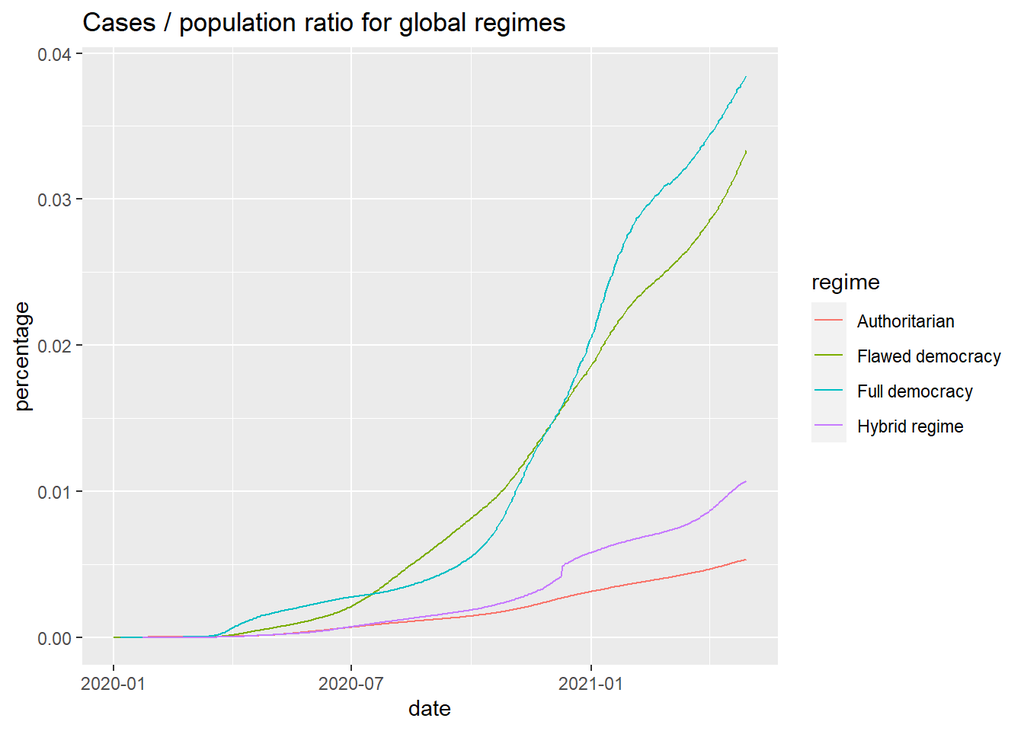

```r
covid_cases1 <- covid_cases %>%
  select(c("location", "date", "total_cases"))

democracyindex1 <- democracyindex %>%
  rename(location = Country, regime = "Regime type") %>%
  select(c("location", "regime"))

population1 <- population %>%
  rename(location = name, population = value) %>%
  select(c("location", "population"))

covid_joined3 <- left_join(covid_cases1, population1, by = "location") %>%
  left_join(democracyindex1, by = "location") %>%
  filter(!is.na(regime)) %>%
  group_by(regime, date) %>%
  summarise(total_cases = sum(total_cases, na.rm = TRUE), population = sum(population, na.rm = TRUE)) %>%
  mutate(percentage = total_cases / population)

covid_joined3 %>%
  filter(isPeriod0(date)) %>%
  ggplot(aes(x = date, y = percentage, group = regime, color = regime)) +
  ggtitle("Cases / population ratio for global regimes") +
  geom_line()
```

FINALLY a hypothesis that turned out to be correct! As you can see by the results, the countries that are more democratic tend to have a higher rate of infection, whereas the countries that are more stringent have a smaller rate of infection.

This does not necessarily mean that the regime policies created an impact on the spread alone. We must also factor in population *size*. A largely populated area will tend to be prone to infections. It seems that the more populated countries are democratic, which in turn result in more infections. This is all speculation of course. One thing is for sure though:

> Democracies have higher infection rates than authoritarian regimes.

## Conclusion

This project has been really fun to tackle. I initially wanted to cram as many conspiracy theories as possible into my hypotheses in order to see which one’s were true or not. However, time did not permit me to splurge on ideas, hence I present you with these three humble statements.

This project improved my comfort with R overall. Knowing how to join datasets is an extremely helpful skill, especially when the data is sprawling with different conventions (tidy or untidy).

I also learned that vaccines are not the end-all solution. Despite the world getting vaccinating, there is no visible decline in global cases of COVID. The deaths aren’t going down either. This is pretty negative news to all the cynicalists I’m not sure exactly how much intervention we have caused to hinder the spread of COVID, given the underwhelming data, but at least it has altered my view on the sentiment, “Vaccines is stopping COVID-19! Look at the decreases! Pfizer/Moderna is the final solution.” Overall, this is very bad news for incentivizing COVID-19 vaccines. Since there is no decrease of cases due to vaccinations, this could cause a pushback against vaccine passports and others.

Another thing that I learned is that, people who claim that vaccines cause infertility were just spouting it on a basis of hysteria. At the time there was no way to prove that the vaccines caused infertility, and there STILL isn’t enough time to conclude that vaccines cause infertility. People like to jump the gun. My lesson is to not accept theories at face value when they are conceived very early on and/or are fueled by hysteria.

Lastly, Totalitarian countries are doing *something* right! Just look at their low cases! Indeed, the more stringent countries have a lower increase of COVID cases than democratic countries. This could either be chalked up to smaller populations, or more hopefully, due to more serious COVID laws.

Thank you for reading my report!

# Meizhu Wang Report

*Return to Introduction*

**Public debt and COVID-19:**

When a country has a large portion of public debt, it means the country owe much to their citizens. In this case, when an unintentional crisis comes such as COVID-19, the ability of handle the crisis and recovery might be suffered. Defining the relationship between the COVID-19 and the public debt would help a country to reconsider the portion of their debt and reduce the risk to experience an out of controlled crisis. Under COVID-19, the economy has recession that many people lose their jobs and must stay at home without earnings. To make the society stable, governments need to spend on subsidies and help economy recovery. However, with large portion of public debt, governments have less money available that can be spent on the important industry such as the health caring or hospital and other essential infrastructures. In this way, we assume that with a larger portion of public debt would decreases the performance against COVID-19(slower vaccination, more cases, more death per million). To clarify the difference between the country with different public debt, before May 01 and between May and Sept. would be better to see the difference in countries or territories ability to deal with the crisis. We pick `total cases`,`new cases`,`total deaths`, `ICU patients`, and `positive rate` to analyze the relationship between the public debt and COVID-19. First, we pick top ten and bottom 9 countries of the public debt and construct the graphs on 5 variables.(Colored based on whole world/Black based on Top 10 &bottom 9 countries/territories)

```r
covid<-covid_cases%>%filter(date<=ymd("2021-05-01")|date>=ymd("2021-09-01"))
```

```r
covid_pubdebt<-left_join(publicdebt, covid, by = c("name" = "location"))
pubdebt_top10<-covid_pubdebt%>%filter(ranking<=10|ranking>=199)
```

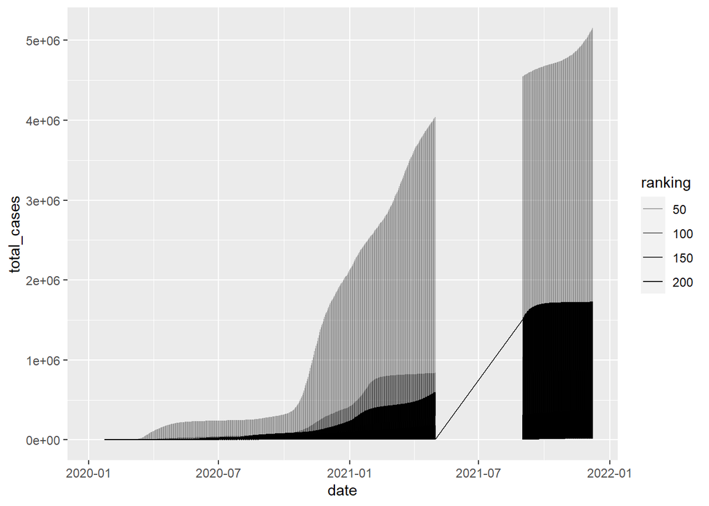

```r
ggplot(pubdebt_top10,mapping = aes(x=date,y=total_cases))+geom_line(mapping = aes(alpha=ranking))
```

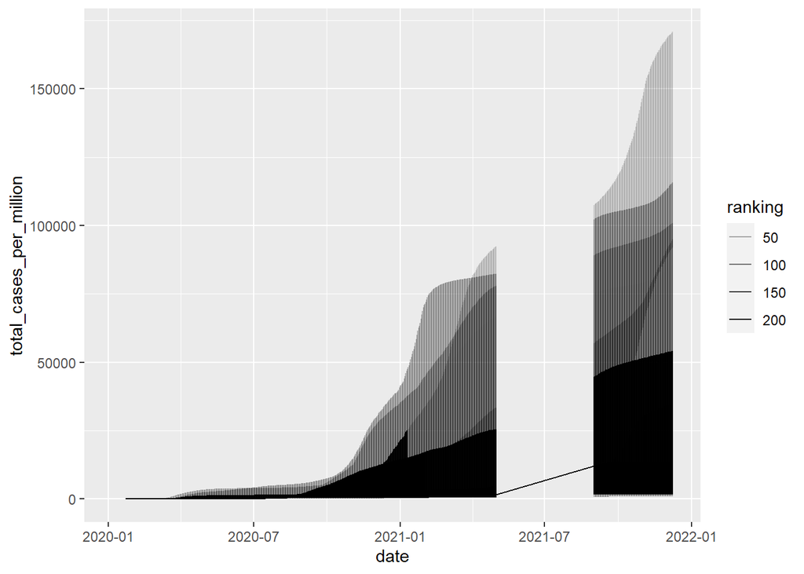

```r
ggplot(pubdebt_top10,mapping = aes(x=date,y=total_cases_per_million))+geom_line(mapping = aes(alpha=ranking))
```

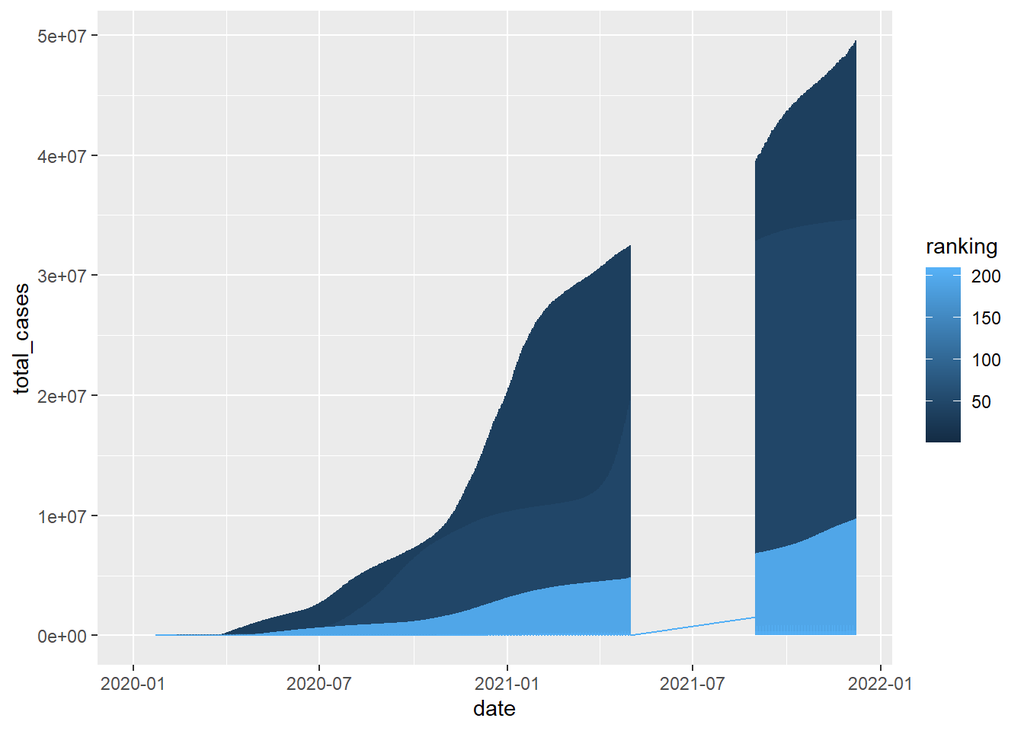

```r
ggplot(covid_pubdebt,mapping = aes(x=date,y=total_cases))+geom_line(mapping = aes(color=ranking))
```

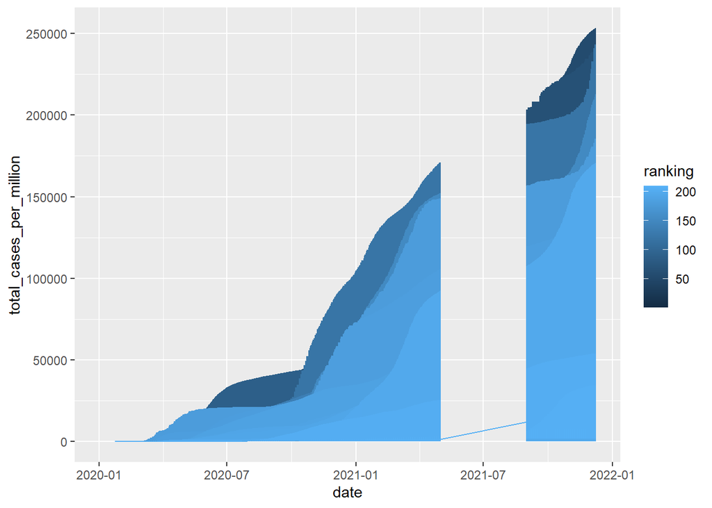

```r
ggplot(covid_pubdebt,mapping = aes(x=date,y=total_cases_per_million))+geom_line(mapping = aes(color=ranking))
```

These graphs focus on the total cases in the top 10 and bottom 9 countries.From the graph of total cases, it is obvious that top 10 country has relatively high total cases with the time increases. Moreover, after Sept 01, bottom 9 countries have almost no increasing in total cases, while top 10 countries still illustrate a upward trend. To avoid the population influence on the analysis, the total cases per million is used to construct the graph again. Although the total cases per million is large for bottom 9 countries, the characteristic found in the first graph is still worked. The pattern is worked on all of the country.

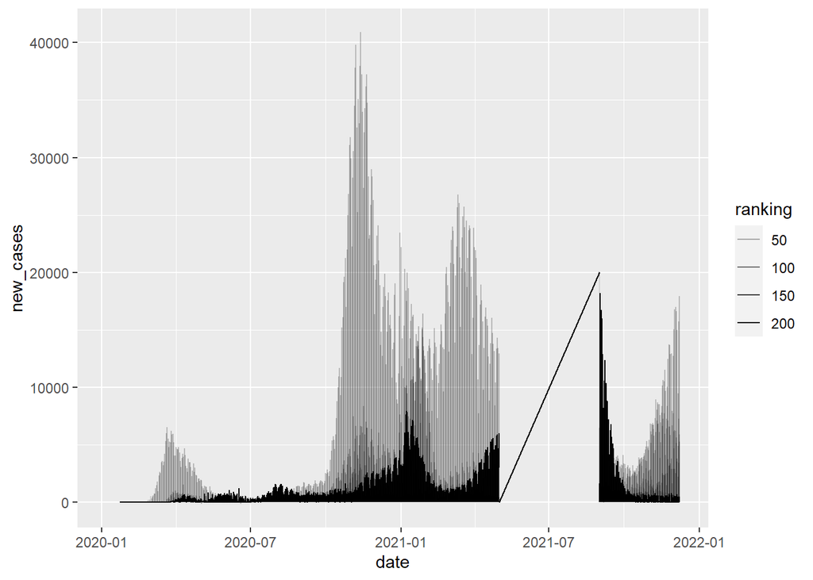

```r
ggplot(pubdebt_top10,mapping = aes(x=date,y=new_cases))+geom_line(mapping = aes(alpha=ranking))
```

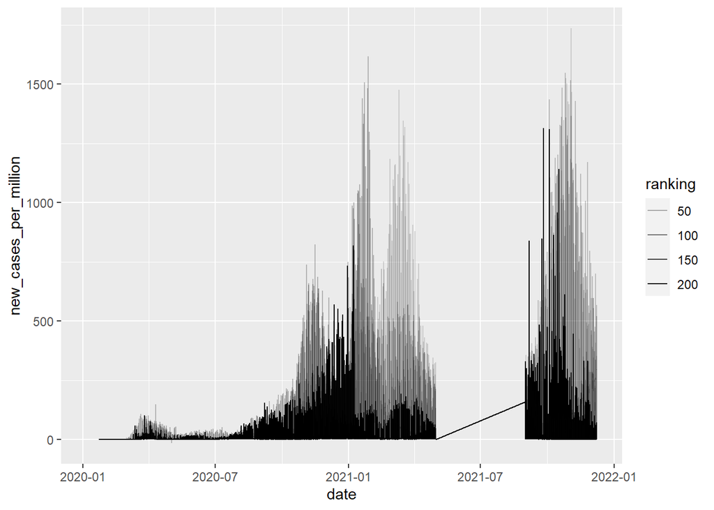

```r
ggplot(pubdebt_top10,mapping = aes(x=date,y=new_cases_per_million))+geom_line(mapping = aes(alpha=ranking))
```

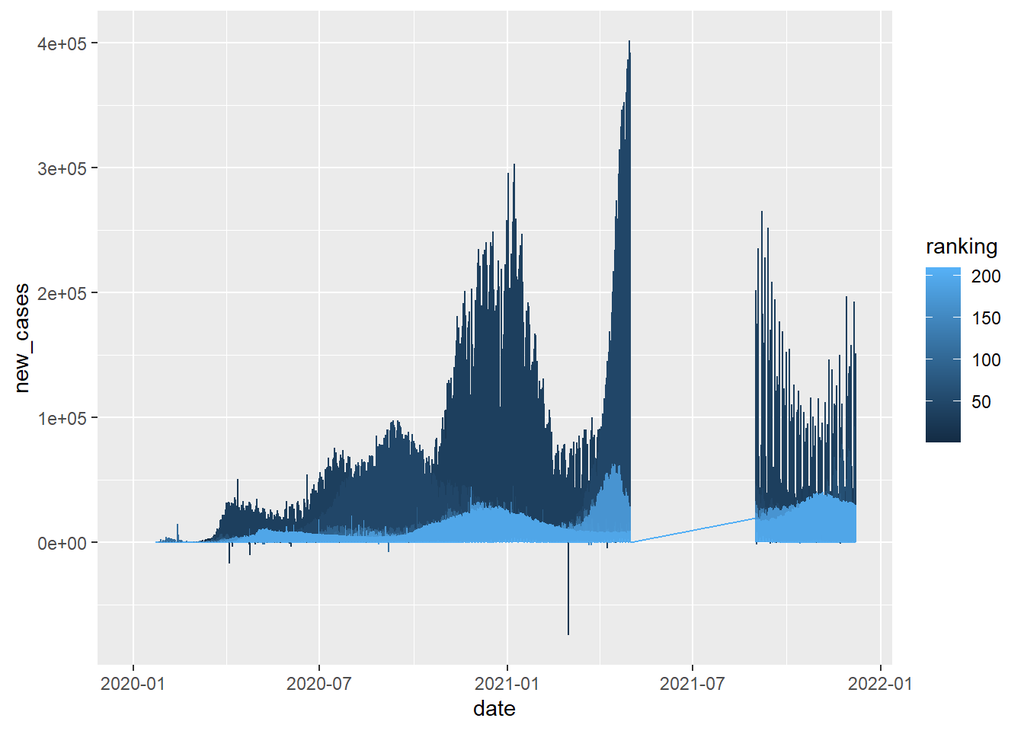

```r
ggplot(covid_pubdebt,mapping = aes(x=date,y=new_cases))+geom_line(mapping = aes(color=ranking))
```

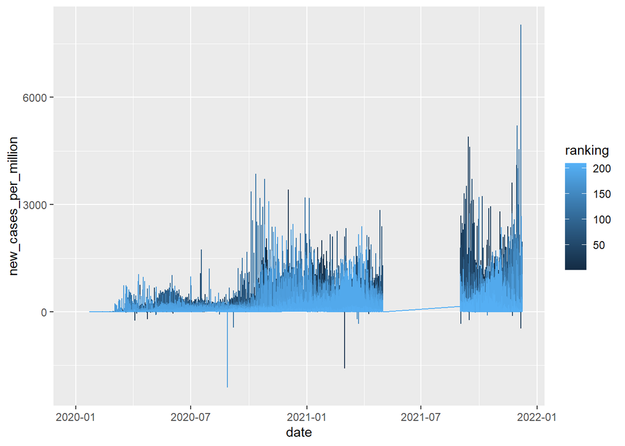

```r
ggplot(covid_pubdebt,mapping = aes(x=date,y=new_cases_per_million))+geom_line(mapping = aes(color=ranking))
```

The graphs related to the new cases are more violated than the total cases. Although, top 10 countries’ new cases are more than bottom 9 countries. Furthermore, top 10 countries has more peaks than bottom 9 countries before May 01, and after Sept 01, the new cases in bottom 9 countries has dramatic decrease compare to an increase in to 10 countries. Besides, before May 01, the distribution of new cases per million for the bottom 9 countries is more right skewed that the peak of the bottom 9 countries’ new cases per million is earlier than top 10 countries’. It also works after Sept 01.

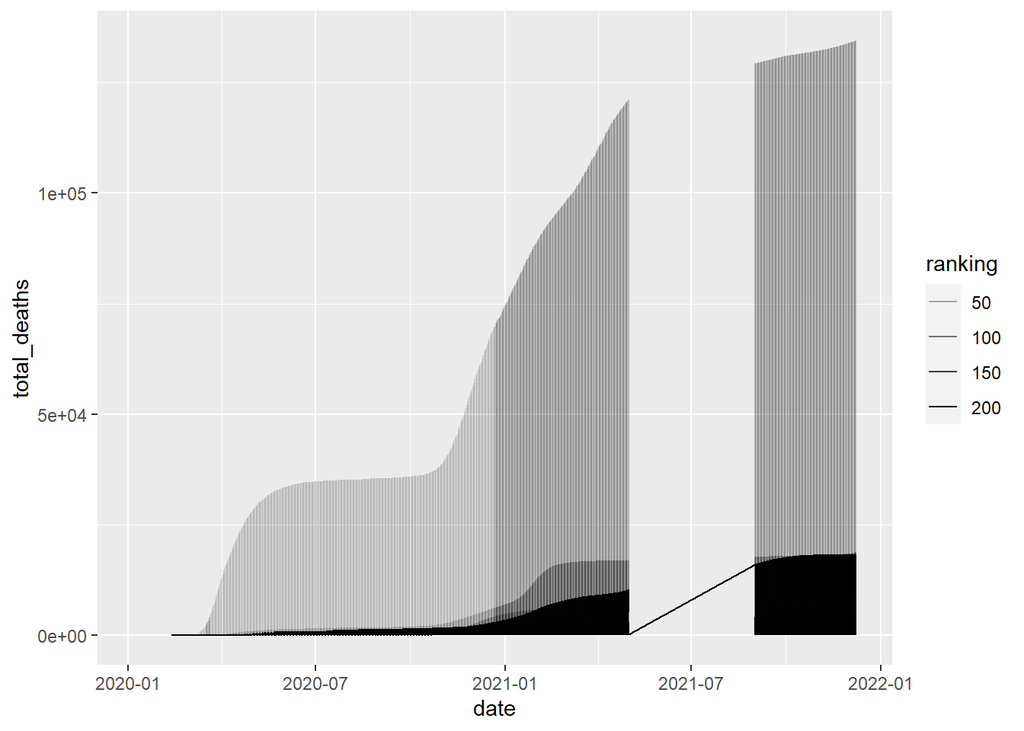

```r
ggplot(pubdebt_top10,mapping = aes(x=date,y=total_deaths))+geom_line(mapping = aes(alpha=ranking))
```

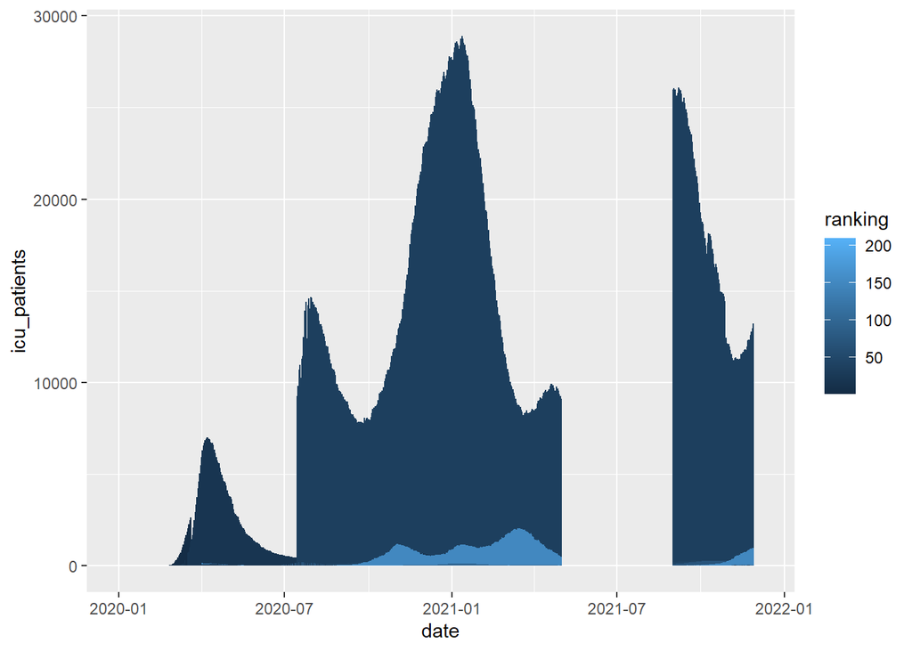

```r
ggplot(covid_pubdebt,mapping = aes(x=date,y=icu_patients))+geom_line(mapping = aes(color=ranking))
```

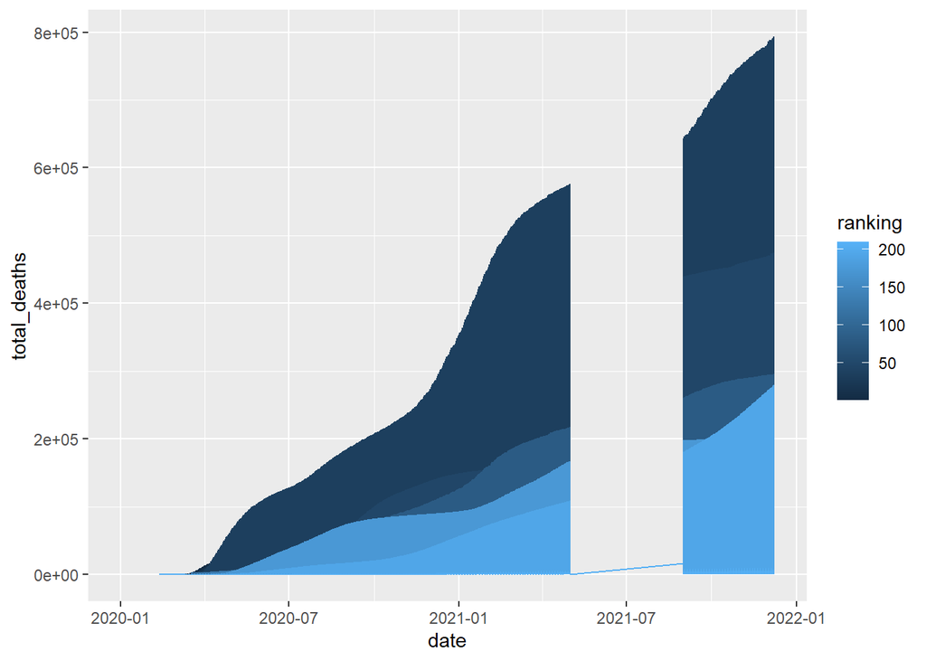

```r
ggplot(covid_pubdebt,mapping = aes(x=date,y=total_deaths))+geom_line(mapping = aes(color=ranking))
```

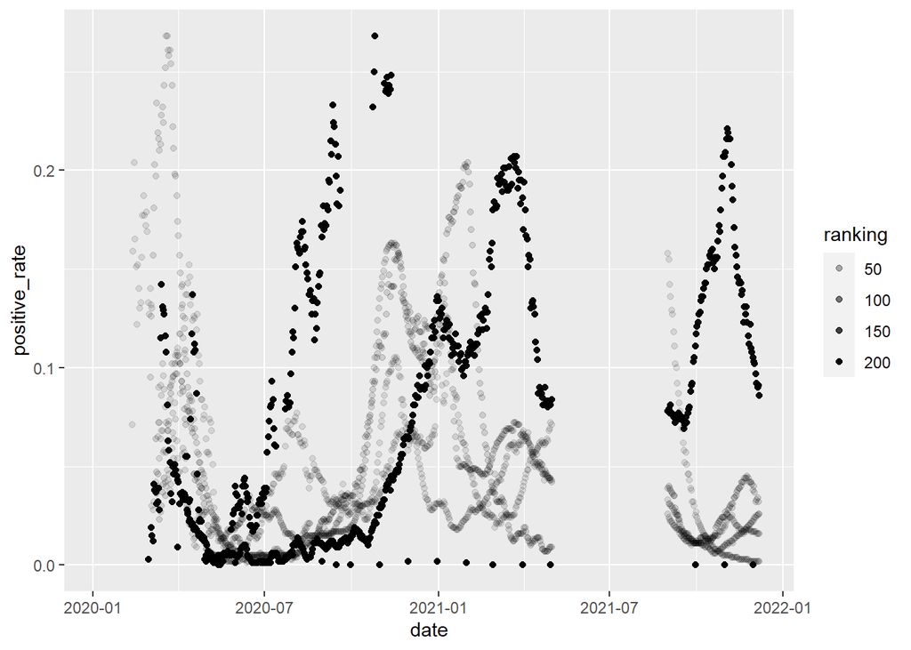

```r
ggplot(pubdebt_top10,mapping = aes(x=date,y=positive_rate))+geom_point(mapping = aes(alpha=ranking))
```

Looking at the total deaths, top 10 countries have far more deaths than bottom 9 countries. Same for the ICU patients, higher ranking countries have more peaks and larger number than lower ranking countries. However, the positive rate seems having different result. It might be caused by the region.

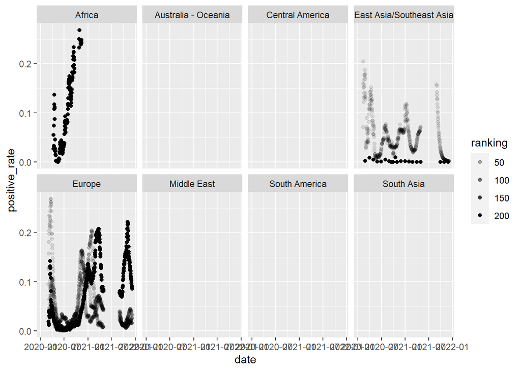

```r
ggplot(pubdebt_top10,mapping = aes(x=date,y=positive_rate))+geom_point(mapping = aes(alpha=ranking))+
  facet_wrap(~region, nrow = 2)
```

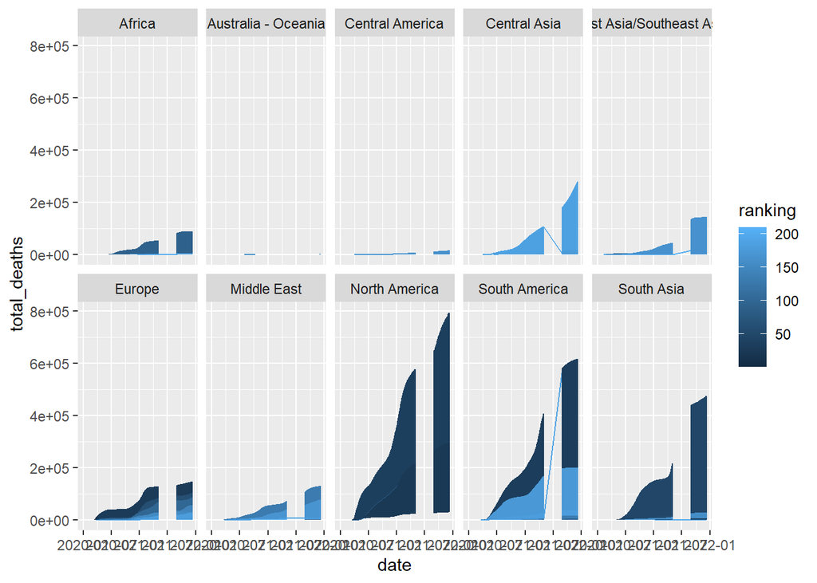

```r
ggplot(covid_pubdebt,mapping = aes(x=date,y=total_deaths))+geom_line(mapping = aes(color=ranking))+
  facet_wrap(~region, nrow = 2)
```

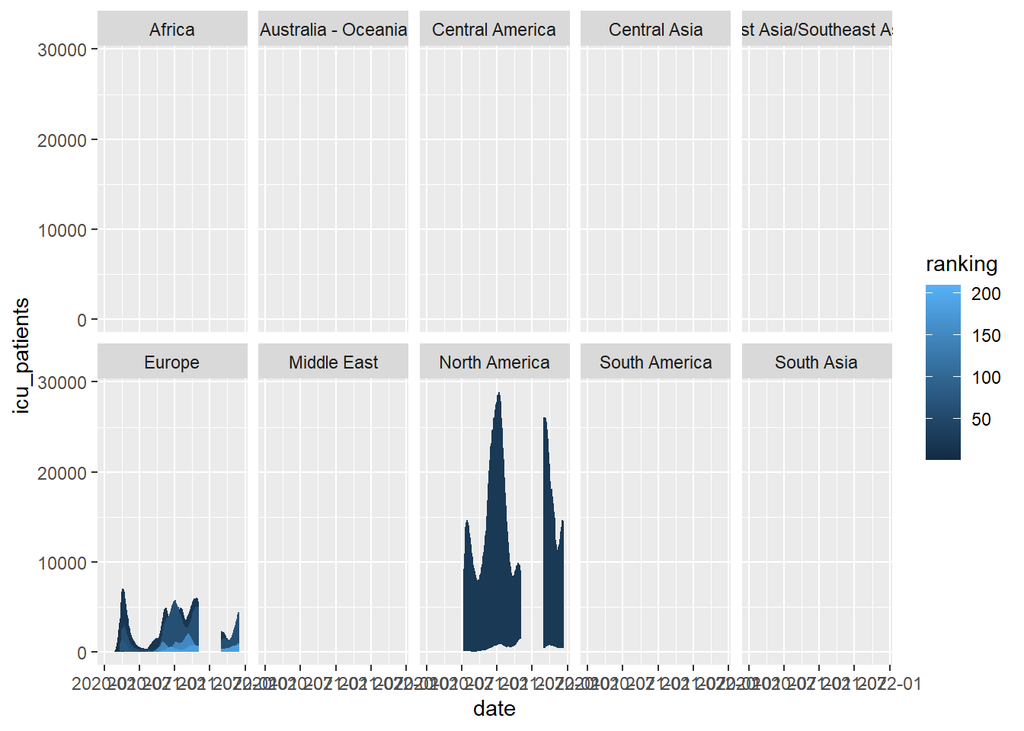

```r
ggplot(covid_pubdebt,mapping = aes(x=date,y=icu_patients))+geom_line(mapping = aes(color=ranking))+
  facet_wrap(~region, nrow = 2)
```

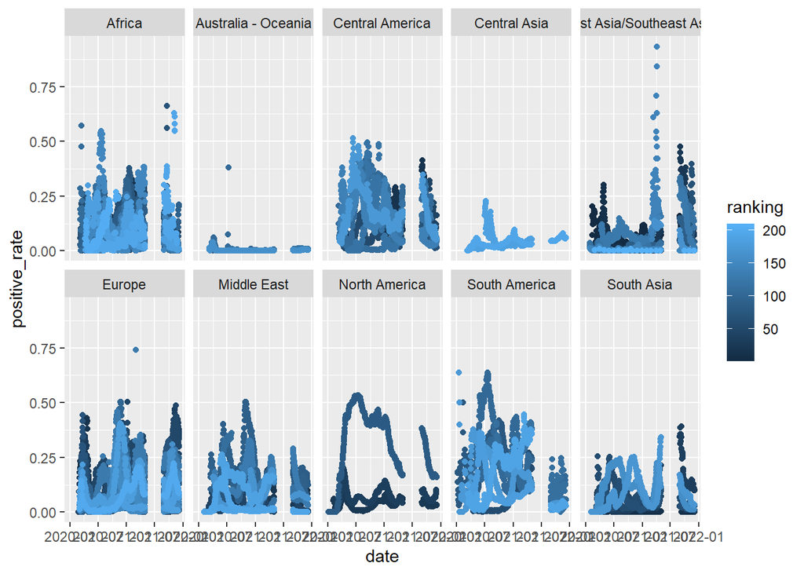

```r
ggplot(covid_pubdebt,mapping = aes(x=date,y=positive_rate))+geom_point(mapping = aes(color=ranking))+
  facet_wrap(~region, nrow = 2)
```

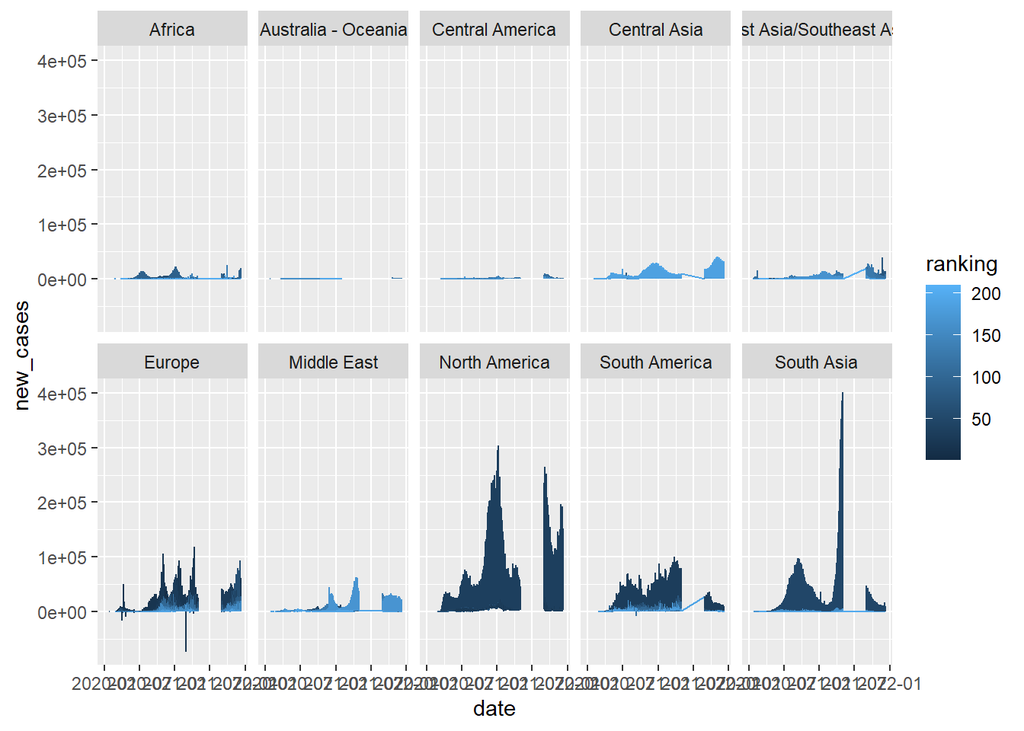

```r
ggplot(covid_pubdebt,mapping = aes(x=date,y=new_cases))+geom_line(mapping = aes(color=ranking))+
  facet_wrap(~region, nrow = 2)
```

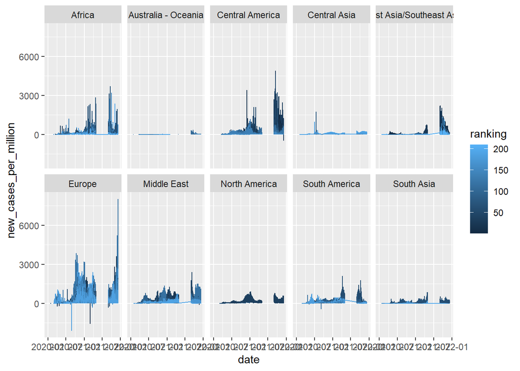

```r
ggplot(covid_pubdebt,mapping = aes(x=date,y=new_cases_per_million))+geom_line(mapping = aes(color=ranking))+
  facet_wrap(~region, nrow = 2)
```

From the first graph, Africa might have low public debt and high positive rate, while East Asia and Europe have high positive rate with high ranking. To analyze the influence from the region, the next five graphs are based on region. European seems been affect by the public debt. North America seems get weak affect by the public debt. When comparing the response variable, the new cases per million is the most clear factor that higher public debt would gets more new cases per million. From the previous analysis, the public debt has impact on the COVID 19 performance of a country. However, the impact might interact or influenced by other factors such as the wealthy of the country, the democracy of the country, or the region of the country.

**Education expenditure and vaccination**

Higher education expenditure always means more attention from government to the education industry. It might address more high-educated people and higher average education level. Furthermore, better educated people may have more knowledge and acceptance about vaccination. In this way, the higher education expenditure might causes the vaccination rate higher. The clarification of the relationship between education expenditure and COVID-19 vaccination could describe a new way to prohibit the spread of pandemic or encourage people to take regular vaccine in normal life. As the COVID vaccine been created, many people criticize the safety of the vaccination. Some of them fear the vaccination. It is interesting that some of those people who fear vaccination may not provide convinced information to prove their points. We assume that they might be lack of the knowledge about the vaccination that caused them refused vaccination. With high education expenditure, it would be considered as high educated country or territories that would have high vaccination rate. The time period are still before May 01 and After Sept 01. The choice based on the random select.

```r
covid_edu<-left_join(educationexp, covid_vaccs, by = c("name" = "location"))%>%filter(date<=ymd("2021-05-01")|date>=ymd("2021-09-01"))
covid_edu_before<-covid_edu%>%filter(date<=ymd("2021-05-01"))%>%select(name,value,region,total_vaccinations,people_fully_vaccinated,people_vaccinated,total_vaccinations_per_hundred,people_fully_vaccinated_per_hundred)%>%group_by(name,region)%>%summarise(total_vaccinations=sum(total_vaccinations,na.rm = TRUE), people_fully_vaccinated=sum(people_fully_vaccinated,na.rm = TRUE),people_vaccinated=sum(people_vaccinated,na.rm = TRUE), total_vaccinations_per_hundred=sum(total_vaccinations_per_hundred,na.rm = TRUE), people_fully_vaccinated_per_hundred=sum(people_fully_vaccinated_per_hundred,na.rm = TRUE),value=mean(value))%>%arrange(value)
covid_edu_after<-covid_edu%>%filter(date>=ymd("2021-09-01"))%>%select(name,value,region,total_vaccinations,people_fully_vaccinated,people_vaccinated,total_vaccinations_per_hundred,people_fully_vaccinated_per_hundred)%>%group_by(name,region)%>%summarise(total_vaccinations=sum(total_vaccinations,na.rm = TRUE), people_fully_vaccinated=sum(people_fully_vaccinated,na.rm = TRUE),people_vaccinated=sum(people_vaccinated,na.rm = TRUE), total_vaccinations_per_hundred=sum(total_vaccinations_per_hundred,na.rm = TRUE), people_fully_vaccinated_per_hundred=sum(people_fully_vaccinated_per_hundred,na.rm = TRUE),value=mean(value))%>%arrange(value)
```

To analyze the relationship, we have pick: total_vaccinations, people_fully_vaccinated, people_vaccinated, total_vaccinations_per_hundred, and people_fully_vaccinated_per_hundred. The data includes all of the five variables’ total before May 01 and after Sept 01.

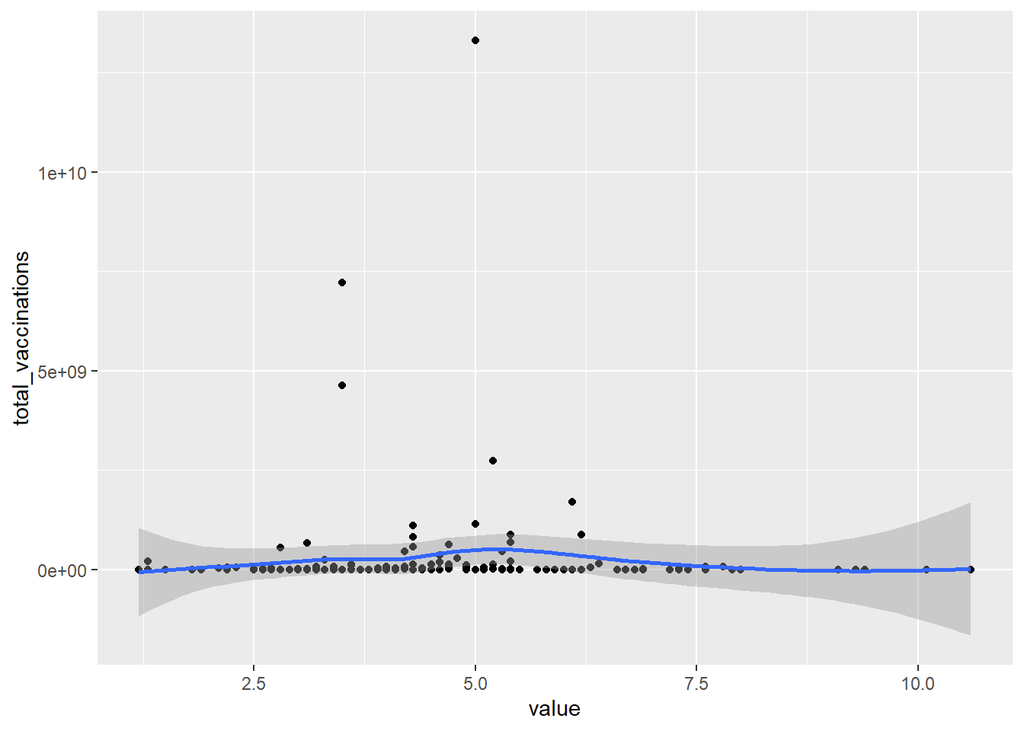

```r
ggplot(covid_edu_before,mapping = aes(x=value,y=total_vaccinations))+geom_point(mapping = aes())+geom_smooth()
```

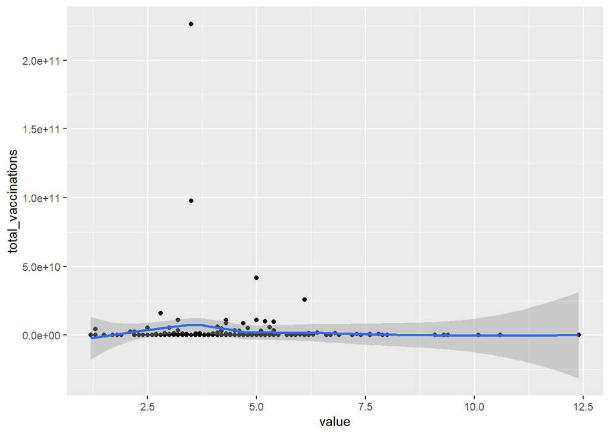

```r
ggplot(covid_edu_after,mapping = aes(x=value,y=total_vaccinations))+geom_point()+geom_smooth()
```

These graphs describe the relationship between total vaccination and the value of education expenditures. Before May 01, we can see small portion of country began vaccination that might cause the immature proceed of producing vaccine. The countries that have positive vaccine are close to the lower part of the education expenditures. Although the increase in the period after Sept 01 is still slight and at lower education expenditures, the increased country before May 01 has more education expenditure comparing to period after Sept 01.

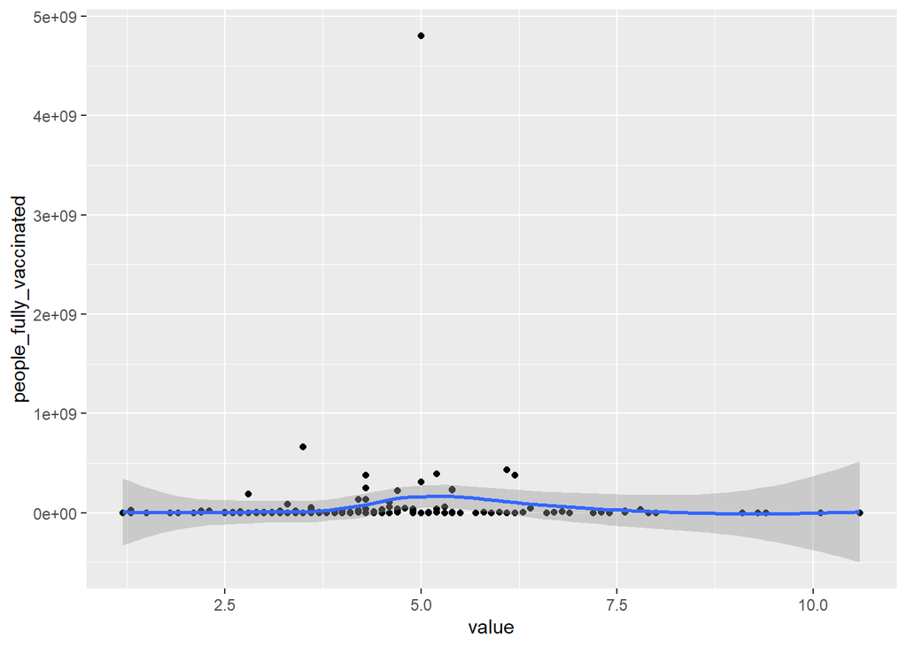

```r
ggplot(covid_edu_before,mapping = aes(x=value,y=people_fully_vaccinated))+geom_point()+geom_smooth()
```